# Cómo transformar datos no normales

RLadies Cuernavaca, Aurora Labastida.

2022-06-15

# Observación preliminar de los datos

```
##                CONT INTG DMNR DILG CFMG DECI PREP FAMI ORAL WRIT PHYS RTEN
## AARONSON,L.H.   5.7  7.9  7.7  7.3  7.1  7.4  7.1  7.1  7.1  7.0  8.3  7.8
## ALEXANDER,J.M.  6.8  8.9  8.8  8.5  7.8  8.1  8.0  8.0  7.8  7.9  8.5  8.7
## ARMENTANO,A.J.  7.2  8.1  7.8  7.8  7.5  7.6  7.5  7.5  7.3  7.4  7.9  7.8
## BERDON,R.I.     6.8  8.8  8.5  8.8  8.3  8.5  8.7  8.7  8.4  8.5  8.8  8.7
## BRACKEN,J.J.    7.3  6.4  4.3  6.5  6.0  6.2  5.7  5.7  5.1  5.3  5.5  4.8
## BURNS,E.B.      6.2  8.8  8.7  8.5  7.9  8.0  8.1  8.0  8.0  8.0  8.6  8.6
```

Empecemos con la columna CONT, que contiene el número de contactos que el abogado ha tenido con el juez.

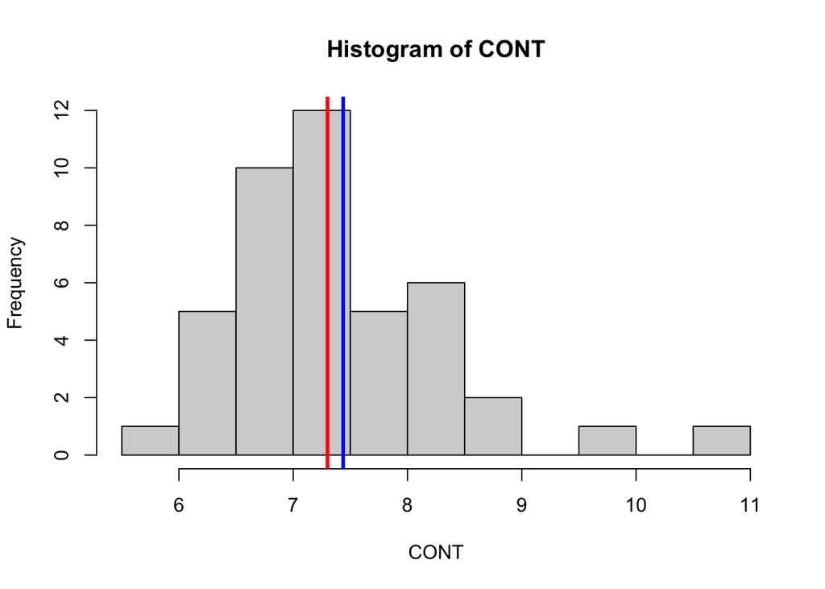

```r
hist(CONT)
abline(v=mean(CONT), col="blue", lwd=3)
abline(v=median(CONT), col="red", lwd=3)
```

También podemos observar el alejamiento de la distribución normal con un qqplot, que muestra la distancia entre los cuantiles calculados a partir de nuestros datos (Sample) y los cuantiles esperados para una distribución normal con el mismo promedio y desviación estándar (Theoretical). Aquí vemos como los cuantiles de la muestra y los teóricos se alejan en el extremo derecho del gráfico.

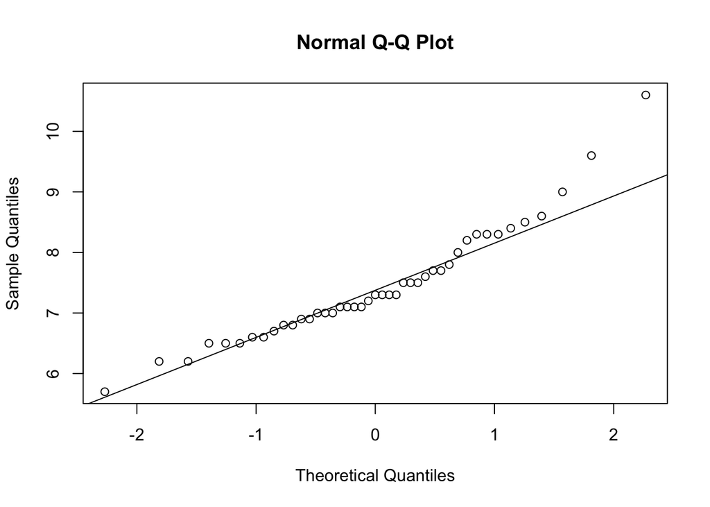

```r
qqnorm(CONT)
qqline(CONT)
```

Veamos de qué tamaño son el sesgo y la curtosis de los datos usando funciones del paquete DescTools

```r
library(DescTools)
Skew(CONT)
```

```
## [1] 1.048311
```

```r
Kurt(CONT)
```

```
## [1] 1.512212
```

El sesgo y la curtosis mayores a cero sugieren desviaciones de la normalidad. Esto es confirmado por el test de Shapiro Wilk, cuya hipótesis nula es que la distribución de los datos es normal, por lo que una p <= 0.05 (o el nivel de significancia de nuestra elección) rechaza la hipótesis de normalidad.

```r
shapiro.test(CONT)$p.value
```

```
## [1] 0.0144497
```

# Transformaciones más conocidas

Para cambiar la forma de los datos podemos usar distintas transformaciones.

**Raíz cuadrada: Para datos con poco sesgo**

```r
CONT_raiz<-sqrt(CONT)
```

**Logaritmo: Para datos con sesgo moderado**

```r
CONT_log10<-log10(CONT)
```

**Inverso : Para datos con mucho sesgo**

```r
CONT_inv<-1/CONT
```

Ahora concatenamos los datos originales y los transformados en un sólo vector

```r
valores<-c(CONT, CONT_raiz, CONT_log10, CONT_inv)
```

Creamos un vector con etiquetas

```r
metodos<-c("Inicial","Raiz","log10","1/x")
metodo_col<-rep(metodos,each=43)
```

Y creamos un data frame con los valores y sus etiquetas

```r
datos<-data.frame(
                  valores=valores,
                  metodo=factor(metodo_col, levels=metodos, ordered="TRUE")
                  )
```

Observemos los datos iniciales y los datos tras distintas transformaciones. Para ello usaremos el paquete ggplot2 y las funciones stat_central_tendency y stat_overlay_normal_density del paquete ggpubr

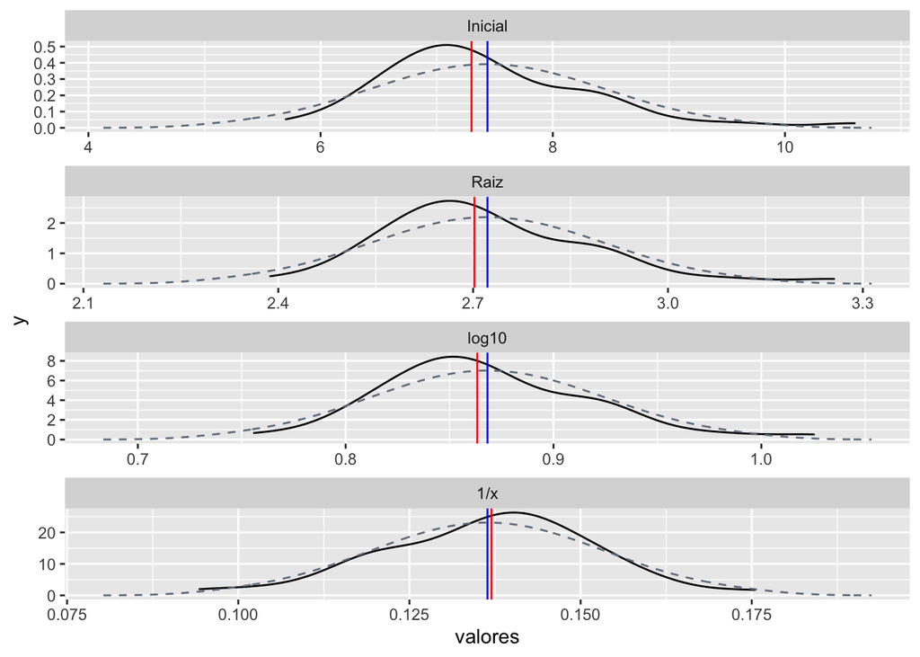

```r
library(ggplot2)
library(ggpubr)

 ggplot(datos, aes(x=valores)) + geom_density() +
  facet_wrap(facets = "metodo", scales="free", ncol=1) +
  stat_central_tendency(type="mean", col="blue") +    #Posición del promedio en azul
  stat_central_tendency(type="median", col="red") +   #Posición de la media en rojo
  stat_overlay_normal_density(col = "slategray", linetype = "dashed") #Distribución normal teórica
```

Vemos cómo la media (azul) y la mediana (rojo) están menos alejadas en los datos transformados que en los originales. Además podemos observar qué tanto se parece cada conjunto de datos a una distribución normal (con mismo promedio y desviación estándar que los datos).

Observemos ahora como el **sesgo** y la **curtosis** se acercan más a cero en los datos transformados

```r
by(datos$valores, datos$metodo, Skew)
```

```
## datos$metodo: Inicial
## [1] 1.048311
## ------------------------------------------------------------
## datos$metodo: Raiz
## [1] 0.8373646
## ------------------------------------------------------------
## datos$metodo: log10
## [1] 0.6328224
## ------------------------------------------------------------
## datos$metodo: 1/x
## [1] -0.2390403
```

```r
by(datos$valores, datos$metodo, Kurt)
```

```
## datos$metodo: Inicial
## [1] 1.512212
## ------------------------------------------------------------
## datos$metodo: Raiz
## [1] 0.9831178
## ------------------------------------------------------------
## datos$metodo: log10
## [1] 0.5854842
## ------------------------------------------------------------
## datos$metodo: 1/x
## [1] 0.1590647
```

También podemos generar un qqplot. Esta vez utilizaremos la función ggqqplot del paquete ggpubr.

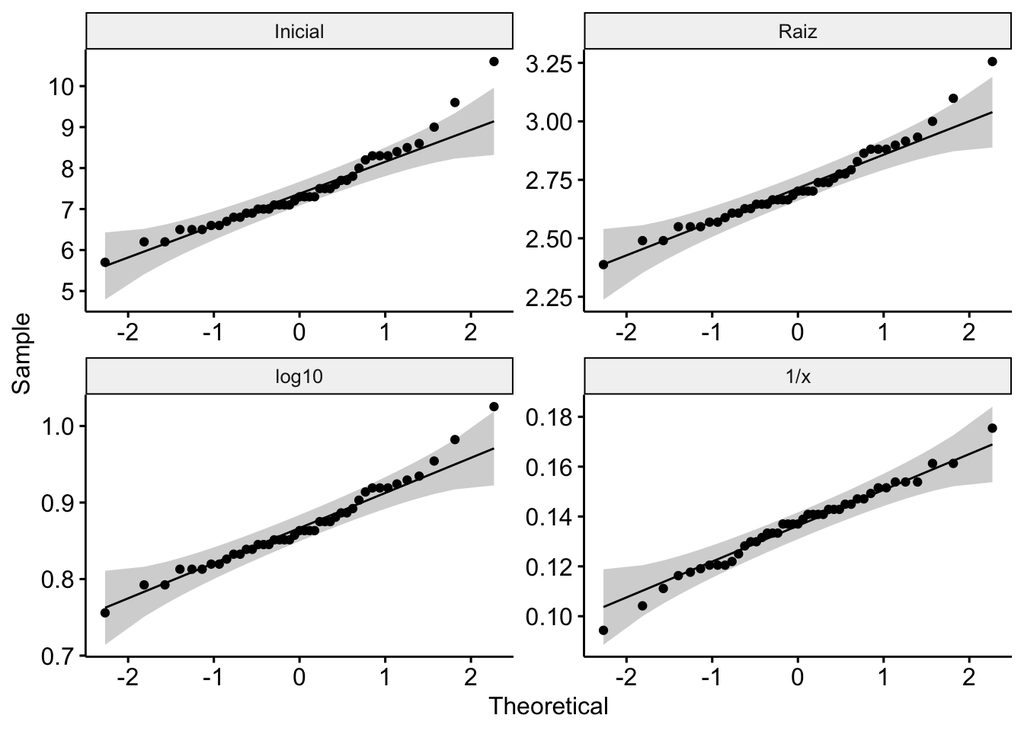

```r
library(ggpubr)
ggqqplot(datos, x="valores")+facet_wrap(facets = "metodo", scales="free", ncol=2)
```

Finalmente, el test de Shapiro Wilk indica que los datos transformados no se desvían significativamente de una distribución normal (p > 0.05)

```r
by(datos$valores, datos$metodo, shapiro.test)
```

```
## datos$metodo: Inicial
##
##  Shapiro-Wilk normality test
##
## data:  dd[x, ]
## W = 0.93274, p-value = 0.01445
##
## ------------------------------------------------------------
## datos$metodo: Raiz
##
##  Shapiro-Wilk normality test
##
## data:  dd[x, ]
## W = 0.95224, p-value = 0.07198
##
## ------------------------------------------------------------
## datos$metodo: log10
##
##  Shapiro-Wilk normality test
##
## data:  dd[x, ]
## W = 0.96773, p-value = 0.2635
##
## ------------------------------------------------------------
## datos$metodo: 1/x
##
##  Shapiro-Wilk normality test
##
## data:  dd[x, ]
## W = 0.98627, p-value = 0.8797
```

# Transformanción de datos con sesgo negativo

La columna INTG del set de datos USJudgeRatings, que tiene los scores de “integridad” de los jueces.

```r
INTG<-USJudgeRatings$INTG
```

Estos datos tienen sesgo negativo (cola a la izquierda)

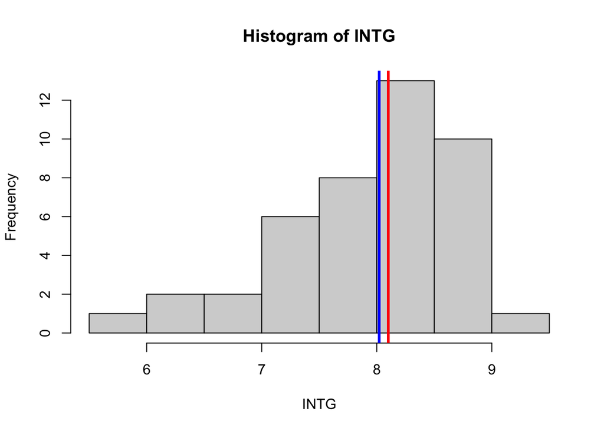

```r
hist(INTG)
abline(v=mean(INTG), col="blue", lwd=3)
abline(v=median(INTG), col="red", lwd=3)
```

En este caso debemos reflejar los datos antes de transformarlos. Para ello:

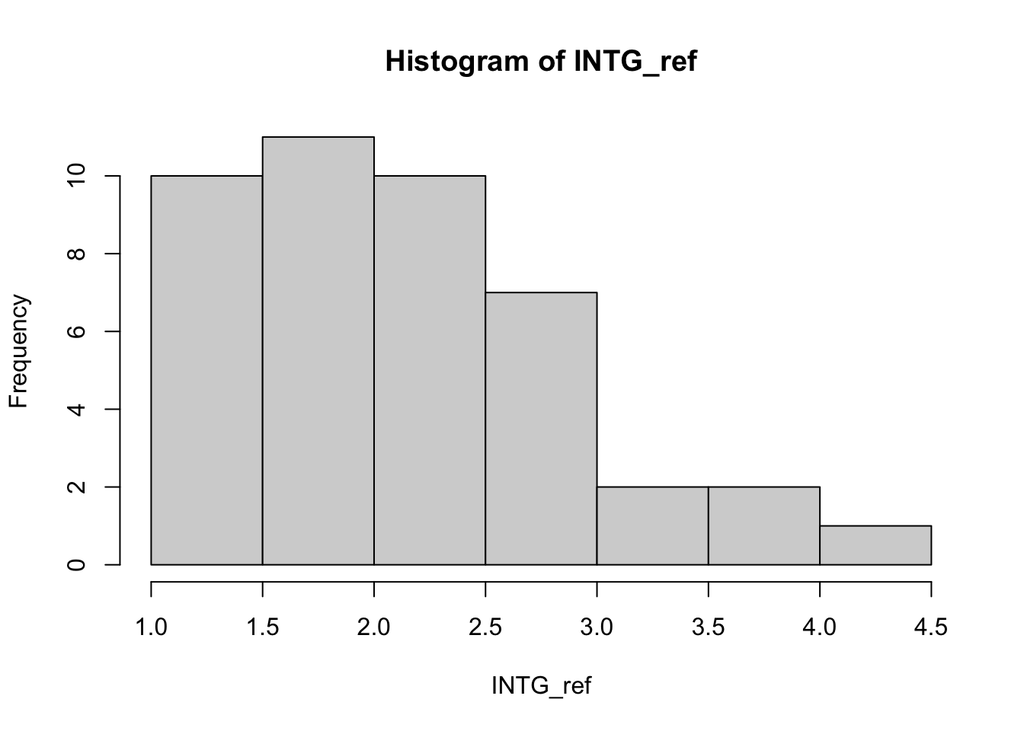

```r
INTG_ref<-max(INTG+1) - INTG
hist(INTG_ref)
```

Ahora sí, realizamos las transformaciones de los datos.

```r
INTG_raiz<-sqrt(INTG_ref)

INTG_log10<-log10(INTG_ref)

INTG_inv<-1/INTG_ref
```

Nuevamente usamos histogramas y qqplots para observar el efecto de las transformaciones

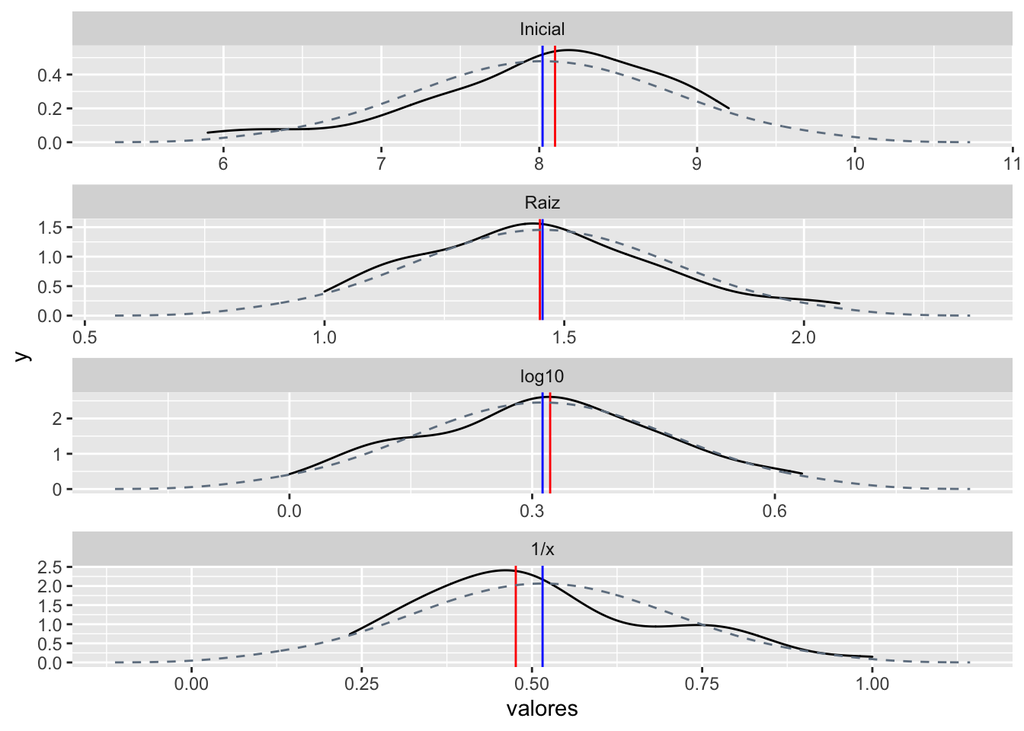

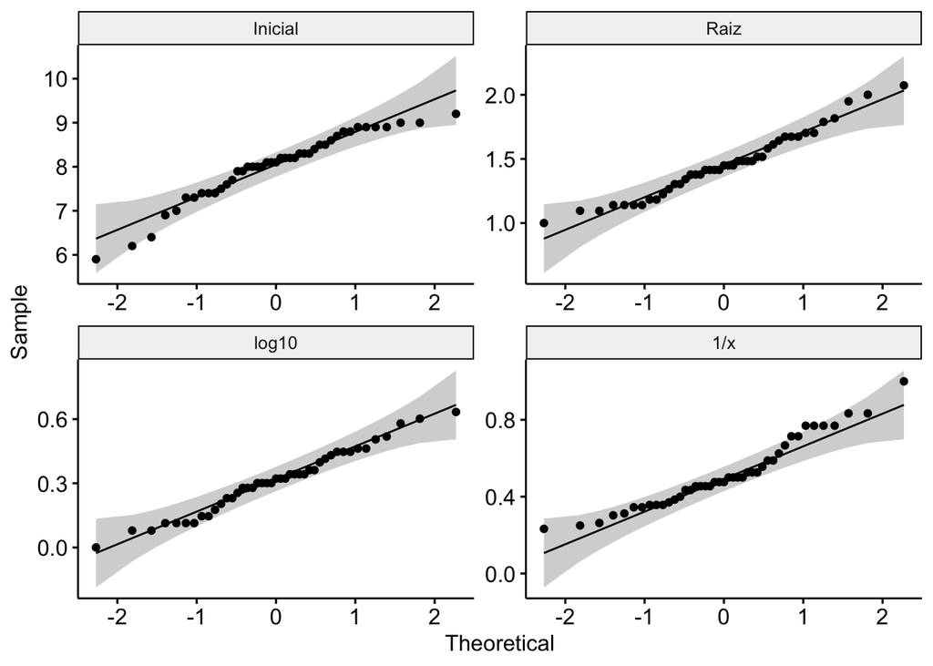

# Herramientas de transformación automática de R

Distintos paquetes de R incluyen herramientas para la transformación de datos no normales en normales. En seguida se muestran algunos de ellos.

Paque LambertW, función Gaussianize

```r
library("LambertW")
CONT_Gauss<-as.numeric(Gaussianize(CONT))
```

```r
library("rcompanion")
CONT_tukey<-as.numeric(transformTukey(CONT))
```

```r
library("forecast")
CONT_BoxCox<-BoxCox(CONT, lambda=BoxCox.lambda(CONT))
```

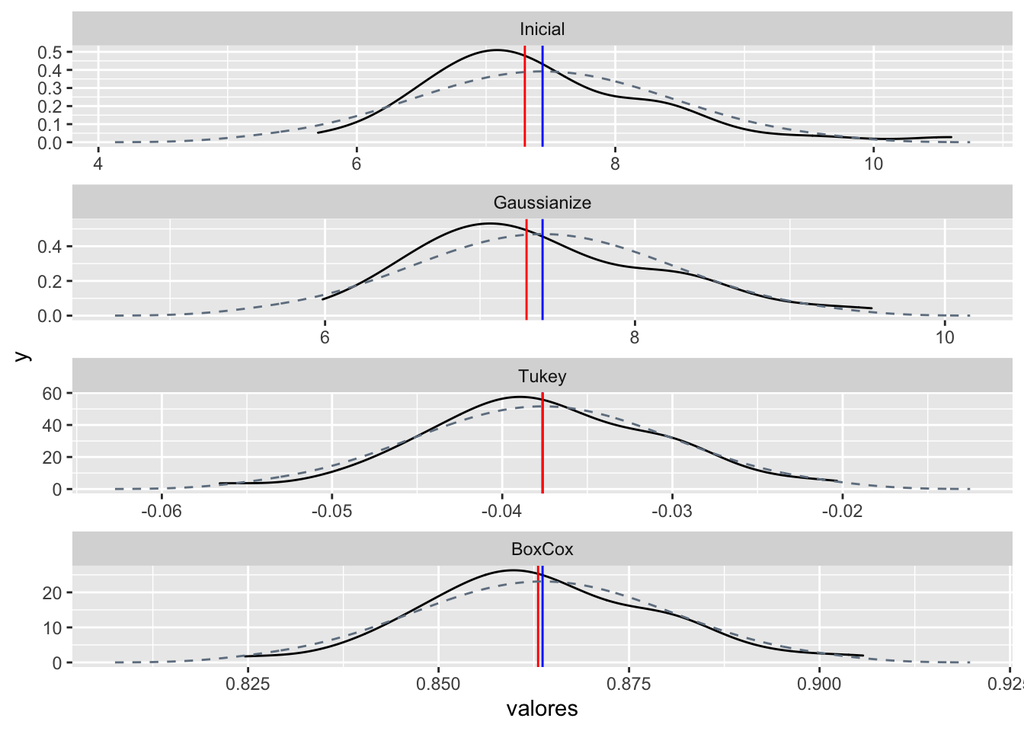